# Homework_10

Ely P. Remes

2024-04-03

### Question 1

Using a for loop, write a function to calculate the number of zeroes in a numeric vector. Before entering the loop, set up a counter variable counter <- 0. Inside the loop, add 1 to counter each time you have a zero in the vector. Finally, use return(counter) for the output.

```r
source("Homework_09Functions.R")
x<- rep(1:10, times=25)

rows<-5
columns<-4

zero_counter<-function(vec){

  counter<-0
  for (i in vec){
    if (i == 0){
      counter<- counter+1
    }
  }

  return(counter)
}
print(zero_counter(vec=x))
```

```
## [1] 0
```

### Question 2

Use subsetting instead of a loop to rewrite the function as a single line of code.

```r
SubsetOfZero<-function(vec){
  return(sum(vec == 0))
}
print(SubsetOfZero(vec=x))
```

```
## [1] 0
```

### Quetion 3

Write a function that takes as input two integers representing the number of rows and columns in a matrix. The output is a matrix of these dimensions in which each element is the product of the row number x the column number.

```r
EasyMatrix<-function(rows=x,columns=y){

  m<-matrix(nrow=rows,ncol=columns)
  for(i in 1:nrow(m)) {
    for(j in 1:ncol(m)) {
     m[i,j]<- i*j
    }
  }
  return(m)
}
EasyMatrix(rows=7,columns=3)
```

```
##      [,1] [,2] [,3]
## [1,]    1    2    3
## [2,]    2    4    6
## [3,]    3    6    9
## [4,]    4    8   12
## [5,]    5   10   15
## [6,]    6   12   18
## [7,]    7   14   21
```

### Question 4A

Now let’s practice calling custom functions within a for loops. Use the code from previous lectures on loops and functions to complete the following steps:

Simulate a dataset with 3 groups of data, each group drawn from a distribution with a different mean. The final data frame should have 1 column for group and 1 column for the response variable

```r
nName= c("Potatoes","Carrots","Radishes")
nSize= c(rep(20, times=3))
nMean= c(17,25, 19)
nSD= c(runif(3))

VeggieWeight<-FakeDataGeneration()

print(head(VeggieWeight))
```

```
## # A tibble: 6 × 3
##   Index Treatment Value
##   <int> <chr>     <dbl>
## 1     1 Potatoes   17.0
## 2     2 Potatoes   17.1
## 3     3 Potatoes   17.2
## 4     4 Potatoes   16.9
## 5     5 Potatoes   16.7
## 6     6 Potatoes   17.5
```

### Question 4B

Write a custom function that 1) reshuffles the response variable, and 2) calculates the mean of each group in the reshuffled data. Store the means in a vector of length 3.

```r
Randomizer<-function(x){


CleanWeight<-mutate(x, Treatment,Value=round(Value, digits=1))
NewWeight<-sample(CleanWeight$Value)



MixedWeight<-mutate(CleanWeight, Treatment, NewWeight)
MixedWeight<-select(MixedWeight, Treatment, NewWeight)

Answer<-group_by(MixedWeight, Treatment) %>% summarize(m = mean(NewWeight))
return(unlist(Answer[,2]))
}



print(head(Randomizer(x=VeggieWeight)))
```

```
##     m1     m2     m3
## 19.690 20.255 21.055
```

### Question 4C

Use a for loop to repeat the function in b 100 times. Store the results in a data frame that has 1 column indicating the replicate number and 1 column for each new group mean, for a total of 4 columns.

```r
FrameWork<- data.frame(matrix(nrow=100,ncol=3))

for (i in 1:nrow(FrameWork)) {
  FrameWork[i,]<-Randomizer(x=VeggieWeight)
}

FrameWork<-mutate(FrameWork, ID=(1:100))
FrameWork<-select(FrameWork, ID,Potatoes=X1,Carrots=X2,Radishes=X3)

print(head(FrameWork))
```

```
##   ID Potatoes Carrots Radishes
## 1  1   19.525  20.230   21.245
## 2  2   20.435  21.160   19.405
## 3  3   20.540  21.215   19.245
## 4  4   20.955  19.035   21.010
## 5  5   20.605  20.225   20.170
## 6  6   21.530  20.320   19.150
```

### Question 4D

Use qplot() to create a histogram of the means for each reshuffled group. Or, if you want a challenge, use ggplot() to overlay all 3 histograms in the same figure. How do the distributions of reshuffled means compare to the original means?

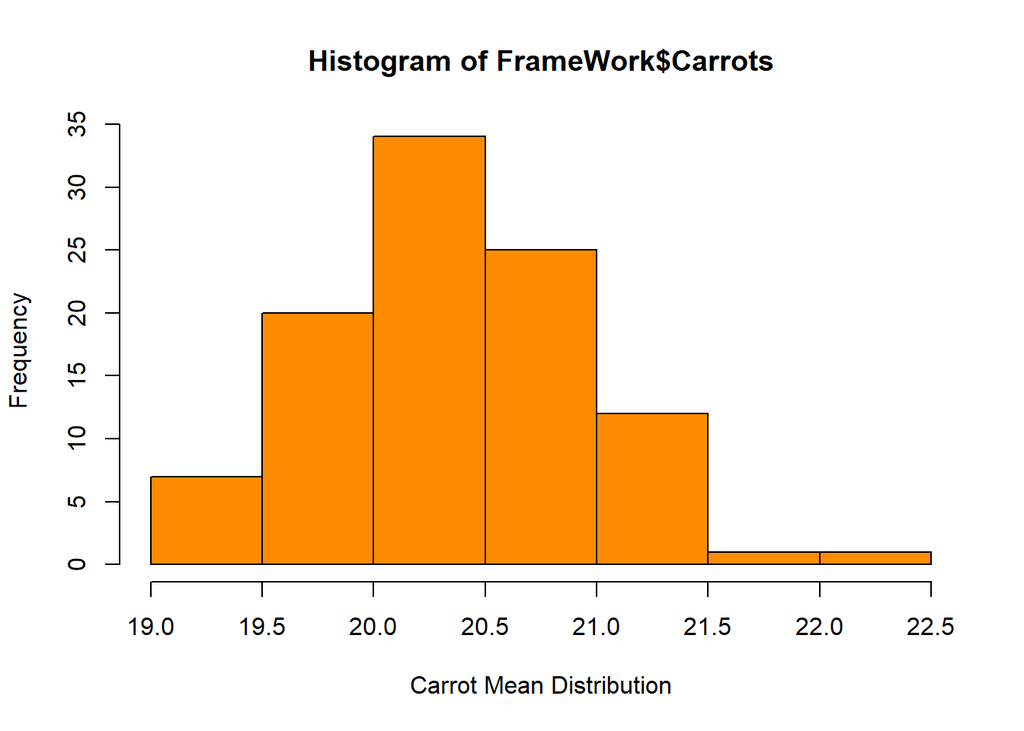

[output not shown]

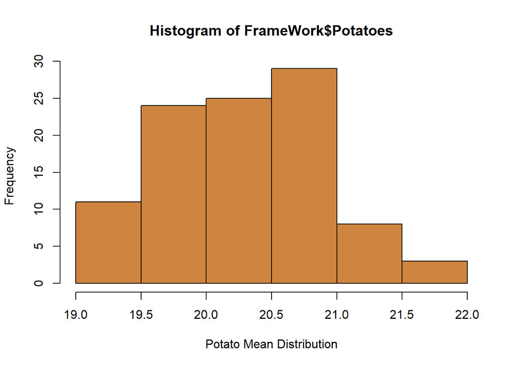

[output not shown]

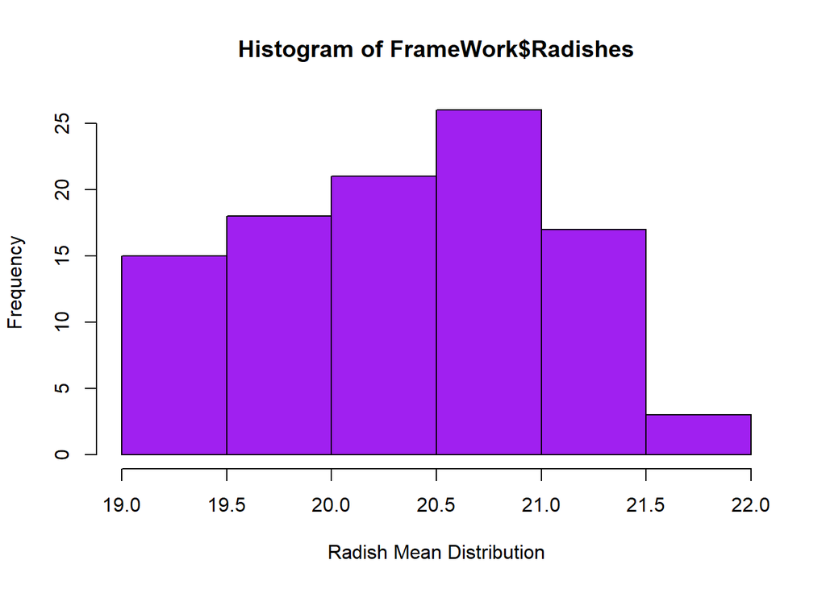

[output not shown]